# Spotify API

networks

homework

grateful network

Final Project Work DACSS 697E course ‘Social and Political Network Analysis’

Kristina Becvar https://www.kristinabecvar.com  
04-18-2022

## “spotifyr” Package

I have been discussing ways to examine the ongoing [Grateful Dead songwriting network data](https://www.kristinabecvar.com/blog.html#category:grateful_network) more thoroughly, and was introduced to the [“spotifyr” package by Charlie Thompson](https://www.rcharlie.com/spotifyr/).

### Creating an Access Token

Using the documentation for the “spotifyr” package and the [Spotify Developer site](https://developer.spotify.com/), I created my access token to pull the data from the Spotify API. I will not run it again in this post, but the process is documented:

```r
#id <- 'xxxxx'
#secret <- 'xxxxx'
#Sys.setenv(SPOTIFY_CLIENT_ID = id)
#Sys.setenv(SPOTIFY_CLIENT_SECRET = secret)
#access_token <- get_spotify_access_token()
```

### Importing Data

The “spotifyr” package offers functions such as “get_artist_audio_features()”, which I pulled for the Grateful Dead, and wrote the data to a file for pulling back into this blog post.

```r
#grateful_dead <- get_artist_audio_features('grateful dead')
grateful_dead <- read_rds("grateful_dead.rds")
gd_spotify <- as_tibble(grateful_dead)
gd_songs <- gd_spotify %>%
  dplyr::select(danceability:tempo, track_name, track_number, track_id, album_name, album_id, time_signature, duration_ms, key_name, mode_name, key_mode)
#saveRDS(grateful_dead, file = "grateful_dead.rds")
write_csv(gd_songs, file = "gd_songs_spotify.csv")
head(gd_songs) %>%
  kable()
```

| danceability | energy | key | loudness | mode | speechiness | acousticness | instrumentalness | liveness | valence | tempo | track_name | track_number | track_id | album_name | album_id | time_signature | duration_ms | key_name | mode_name | key_mode |
| --- | --- | --- | --- | --- | --- | --- | --- | --- | --- | --- | --- | --- | --- | --- | --- | --- | --- | --- | --- | --- |
| 0.593 | 0.509 | 9 | -16.044 | 1 | 0.0513 | 0.611 | 8.56e-04 | 0.827 | 0.530 | 116.270 | Cold Rain And Snow - Live 1982 | 1 | 1Gzd8R2897JtsdWqtTeVnB | New Year’s Eve ’82 (Live) | 3YAidBiP3mJaeOV02C5LUm | 4 | 394248 | A | major | A major |
| 0.404 | 0.651 | 2 | -15.260 | 1 | 0.0689 | 0.670 | 2.70e-02 | 0.979 | 0.613 | 132.572 | CC Rider - Live 1982 | 2 | 5CyOpUGRyco3LB0dnZ7SOB | New Year’s Eve ’82 (Live) | 3YAidBiP3mJaeOV02C5LUm | 1 | 546191 | D | major | D major |
| 0.517 | 0.718 | 7 | -15.504 | 1 | 0.0472 | 0.641 | 2.61e-04 | 0.399 | 0.663 | 124.229 | Cumberland Blues - Live 1982 | 3 | 7KPZljz7xnCvdFe1azVaKw | New Year’s Eve ’82 (Live) | 3YAidBiP3mJaeOV02C5LUm | 4 | 326016 | G | major | G major |
| 0.497 | 0.520 | 2 | -15.588 | 1 | 0.0489 | 0.656 | 3.72e-05 | 0.582 | 0.586 | 108.832 | Far From Me - Live 1982 | 4 | 2q7l3fyy6P3JH01zym1NgD | New Year’s Eve ’82 (Live) | 3YAidBiP3mJaeOV02C5LUm | 4 | 277320 | D | major | D major |
| 0.323 | 0.559 | 9 | -15.571 | 1 | 0.0480 | 0.599 | 1.07e-04 | 0.689 | 0.636 | 167.025 | Cassidy - Live 1982 | 5 | 2makttpihU2hK98qaVoyyZ | New Year’s Eve ’82 (Live) | 3YAidBiP3mJaeOV02C5LUm | 4 | 337488 | A | major | A major |
| 0.651 | 0.370 | 2 | -15.451 | 1 | 0.0413 | 0.753 | 6.10e-06 | 0.423 | 0.487 | 114.595 | Ramble On Rose - Live 1982 | 6 | 0hAmS1vb2GHOEpX6nFwBk4 | New Year’s Eve ’82 (Live) | 3YAidBiP3mJaeOV02C5LUm | 4 | 445248 | D | major | D major |

#### Data Details

I saved the pulled data that is relevant to my purposes into a more manageable tibble indicating details such as Spotify’s classification for the track name and ID, album name and ID, track number, song duration (in milliseconds), info about the time and key signature for each song, and classifying traits for song including:

- acousticness (A confidence measure from 0.0 to 1.0 of whether the track is acoustic. 1.0 represents high confidence the track is acoustic.)
- danceability (Danceability describes how suitable a track is for dancing based on a combination of musical elements including tempo, rhythm stability, beat strength, and overall regularity. A value of 0.0 is least danceable and 1.0 is most danceable.)
- energy (Energy is a measure from 0.0 to 1.0 and represents a perceptual measure of intensity and activity. Typically, energetic tracks feel fast, loud, and noisy. For example, death metal has high energy, while a Bach prelude scores low on the scale. Perceptual features contributing to this attribute include dynamic range, perceived loudness, timbre, onset rate, and general entropy.)
- instumentalness (Predicts whether a track contains no vocals. “Ooh” and “aah” sounds are treated as instrumental in this context. Rap or spoken word tracks are clearly “vocal”. The closer the instrumentalness value is to 1.0, the greater likelihood the track contains no vocal content. Values above 0.5 are intended to represent instrumental tracks, but confidence is higher as the value approaches 1.0.)
- key (The key the track is in. Integers map to pitches using standard Pitch Class notation. E.g. 0 = C, 1 = C♯/D♭, 2 = D, and so on. If no key was detected, the value is -1.)
- liveness (Detects the presence of an audience in the recording. Higher liveness values represent an increased probability that the track was performed live. A value above 0.8 provides strong likelihood that the track is live.)
- loudness (The overall loudness of a track in decibels (dB). Loudness values are averaged across the entire track and are useful for comparing relative loudness of tracks. Loudness is the quality of a sound that is the primary psychological correlate of physical strength (amplitude). Values typically range between -60 and 0 db.)
- mode (Mode indicates the modality (major or minor) of a track, the type of scale from which its melodic content is derived. Major is represented by 1 and minor is 0.)
- speechiness (Speechiness detects the presence of spoken words in a track. The more exclusively speech-like the recording (e.g. talk show, audio book, poetry), the closer to 1.0 the attribute value. Values above 0.66 describe tracks that are probably made entirely of spoken words. Values between 0.33 and 0.66 describe tracks that may contain both music and speech, either in sections or layered, including such cases as rap music. Values below 0.33 most likely represent music and other non-speech-like tracks.)
- tempo (The overall estimated tempo of a track in beats per minute (BPM). In musical terminology, tempo is the speed or pace of a given piece and derives directly from the average beat duration.)
- time_signature (An estimated time signature. The time signature (meter) is a notational convention to specify how many beats are in each bar (or measure). The time signature ranges from 3 to 7 indicating time signatures of “3/4”, to “7/4”.)
- valence (A measure from 0.0 to 1.0 describing the musical positiveness conveyed by a track. Tracks with high valence sound more positive (e.g. happy, cheerful, euphoric), while tracks with low valence sound more negative (e.g. sad, depressed, angry).)

### Statistics

#### Classification Means

Grouping by album name, I’m calculating the mean valence, danceability, liveness, and tempo for examining further.

```r
options(scipen = 999)
gd_mean_by_album <- gd_songs %>%
  group_by(album_name) %>%
  summarise(mean_valence = mean(valence),
            mean_danceability = mean(danceability),
            mean_energy = mean(energy),
            mean_liveness = mean(liveness),
            mean_tempo = mean(tempo))
head(gd_mean_by_album) %>%
  kable()
```

| album_name | mean_valence | mean_danceability | mean_energy | mean_liveness | mean_tempo |
| --- | --- | --- | --- | --- | --- |
| 30 Days of Dead 2012 | 0.5855333 | 0.5396333 | 0.3537633 | 0.4658667 | 118.6200 |
| 30 Days of Dead 2013 | 0.6311667 | 0.5170667 | 0.3715567 | 0.5661867 | 127.1120 |
| 30 Days of Dead 2014 | 0.5718667 | 0.5240333 | 0.2957400 | 0.4884500 | 121.5245 |
| 30 Days of Dead 2015 | 0.5873667 | 0.5248667 | 0.3856667 | 0.5414033 | 116.2921 |
| 30 Trips Around the Sun: The Definitive Live Story (1965-1995) | 0.5958065 | 0.5117097 | 0.4358710 | 0.4573097 | 122.2286 |
| American Beauty | 0.6833500 | 0.5801000 | 0.4559500 | 0.2021450 | 121.3004 |

### Top Tracks

I also want to use the “spotifyr” function, “get_artist_top_tracks()” and pull the top 10 Grateful Dead tracks on Spotify. I’m saving the song and album IDs, song and album names, and popularity score, into its’ own data frame for offline and future use as well.

```r
#gd_top_tracks <- get_artist_top_tracks(id='4TMHGUX5WI7OOm53PqSDAT', market="US")
gd_top_spotify <- read_csv("gd_top_spotify.csv")
#gd_top_spotify <- gd_top_tracks %>%
  #dplyr::select()
#write_csv(gd_top_spotify, file = "gd_top_spotify.csv")
head(gd_top_spotify) %>%
  kable()
```

| popularity | rank | track_name | album_name | track_number | track_id | album_id | danceability | energy | key | loudness | mode | speechiness | acousticness | instrumentalness | liveness | valence | tempo | time_signature | duration_ms | key_name | mode_name | key_mode |
| --- | --- | --- | --- | --- | --- | --- | --- | --- | --- | --- | --- | --- | --- | --- | --- | --- | --- | --- | --- | --- | --- | --- |
| 63 | 1 | Friend of the Devil | American Beauty | 2 | 5ZLzl6T8JwqMTMdoE0nCbU | 7rqgm1BnAZ8I4d6hukpkdg | 0.642 | 0.628 | 7 | -12.849 | 1 | 0.0358 | 0.3340 | 0.0000083 | 0.6140 | 0.893 | 103.317 | 4 | 201866 | G | major | G major |
| 62 | 2 | Althea - 2013 Remaster | Go to Heaven | 3 | 7M7AwtGvWdMYudqx5Iuh1m | 6x3mttp1a5pLHj8rDDSEbT | 0.783 | 0.284 | 9 | -14.307 | 1 | 0.0365 | 0.6790 | 0.2820000 | 0.0767 | 0.584 | 82.676 | 4 | 412595 | A | major | A major |
| 61 | 3 | Casey Jones - 2013 Remaster | Workingman’s Dead | 8 | 7LbfuQVct78YoghmoPtsQ8 | 4jxokHekH1qSad1DcC82ku | 0.671 | 0.405 | 0 | -10.052 | 1 | 0.0392 | 0.3850 | 0.0000000 | 0.1320 | 0.828 | 99.678 | 4 | 265067 | C | major | C major |
| 60 | 4 | Touch of Grey - 2013 Remaster | In the Dark | 1 | 0mJQlCl9YgxW7kyeltNiVk | 1KytsXm6VQcyX5B5m8HBNa | 0.612 | 0.696 | 11 | -11.340 | 1 | 0.0353 | 0.0785 | 0.0000094 | 0.1400 | 0.849 | 159.829 | 4 | 350862 | B | major | B major |
| 59 | 5 | Ripple - 2013 Remaster | American Beauty (2013 Remaster) | 6 | 1OE5l6sedVcIFELMuxQOPI | 2UDDZVesmQwA4aYfa55diS | 0.604 | 0.411 | 7 | -14.258 | 1 | 0.0340 | 0.4270 | 0.0000574 | 0.6020 | 0.675 | 126.637 | 4 | 249733 | G | major | G major |
| 58 | 6 | Truckin’ - 2013 Remaster | American Beauty (2013 Remaster) | 10 | 1I6l01BaBgBCVkfQCpIlR6 | 2UDDZVesmQwA4aYfa55diS | 0.644 | 0.623 | 11 | -13.862 | 0 | 0.0590 | 0.3890 | 0.0202000 | 0.0617 | 0.676 | 126.553 | 4 | 306973 | B | minor | B minor |

## Vizualizations

### Heat Map

The first thing I want to look at it the density heat map looking at the mean energy and mean valence of each album. I’m not sure how this may serve my purposes going forward, so I want to look at another visualization.

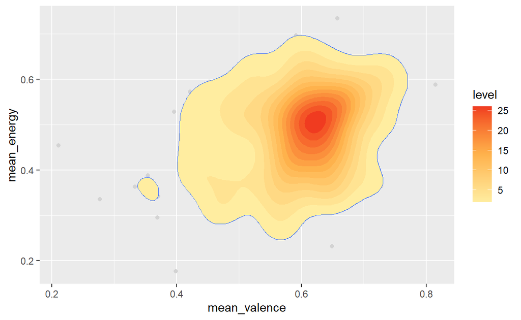

```r
sf <- ggplot(gd_mean_by_album, aes(mean_valence, mean_energy)) +
  geom_point(color = "lightgray")

sf + geom_density_2d() +
   stat_density_2d(aes(fill = ..level..), geom = "polygon") +
  scale_fill_gradientn(colors = c("#FFEDA0", "#FEB24C", "#F03B20"))
```

### Quantiles

Another way to represent the meaningfulness of the mean valence scores is to look at them by quantile.

```
                           Value
valence_percentile_00  0.2106917
valence_percentile_25  0.5606667
valence_percentile_50  0.6073333
valence_percentile_75  0.6507409
valence_percentile_100 0.8146500
```

```r
gd_mean_by_album$Valence_Quartile[gd_mean_by_album$mean_valence >= valence_percentile_00 & gd_mean_by_album$mean_valence < valence_percentile_25]  = "1st Quartile"
gd_mean_by_album$Valence_Quartile[gd_mean_by_album$mean_valence >= valence_percentile_25 & gd_mean_by_album$mean_valence < valence_percentile_50]  = "2nd Quartile"
gd_mean_by_album$Valence_Quartile[gd_mean_by_album$mean_valence >= valence_percentile_50 & gd_mean_by_album$mean_valence < valence_percentile_75]  = "3rd Quartile"
gd_mean_by_album$Valence_Quartile[gd_mean_by_album$mean_valence >= valence_percentile_75 & gd_mean_by_album$mean_valence <= valence_percentile_100]  = "4th Quartile"

head(gd_mean_by_album) %>%
  kable()
```

| album_name | mean_valence | mean_danceability | mean_energy | mean_liveness | mean_tempo | Valence_Quartile |
| --- | --- | --- | --- | --- | --- | --- |
| 30 Days of Dead 2012 | 0.5855333 | 0.5396333 | 0.3537633 | 0.4658667 | 118.6200 | 2nd Quartile |
| 30 Days of Dead 2013 | 0.6311667 | 0.5170667 | 0.3715567 | 0.5661867 | 127.1120 | 3rd Quartile |
| 30 Days of Dead 2014 | 0.5718667 | 0.5240333 | 0.2957400 | 0.4884500 | 121.5245 | 2nd Quartile |
| 30 Days of Dead 2015 | 0.5873667 | 0.5248667 | 0.3856667 | 0.5414033 | 116.2921 | 2nd Quartile |
| 30 Trips Around the Sun: The Definitive Live Story (1965-1995) | 0.5958065 | 0.5117097 | 0.4358710 | 0.4573097 | 122.2286 | 2nd Quartile |
| American Beauty | 0.6833500 | 0.5801000 | 0.4559500 | 0.2021450 | 121.3004 | 4th Quartile |

#### Scatterplots

Basic scatterplots by quartile is somewhat interesting, but I don’t really see that there is a meaningful pattern in the relationship between danceability and energy in the quartile scatterplots.

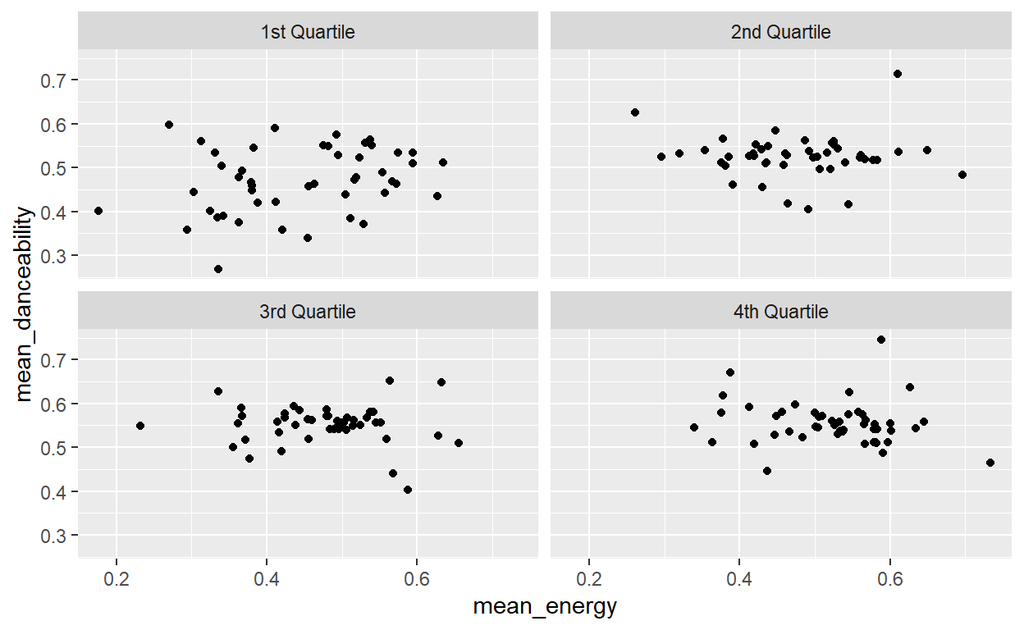

```r
(ggplot(data = gd_mean_by_album) +
  geom_point(mapping = aes(x = mean_energy, y = mean_danceability)) +
  facet_wrap(~ Valence_Quartile, nrow = 2))
```

#### Density Plots

The density plots are a much better way to visualize the differences in the valence quartiles among classification values.

##### Song Energy

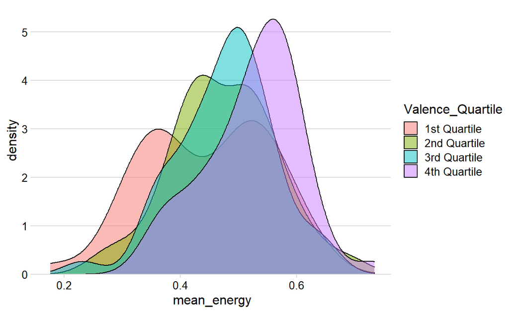

```r
library(cowplot)
ggplot(gd_mean_by_album, aes(mean_energy, fill = Valence_Quartile)) +
  geom_density(alpha = 0.5) +
  scale_y_continuous(expand = expansion(mult = c(0, 0.05))) +
  theme_minimal_hgrid(12)
```

##### Song Danceability

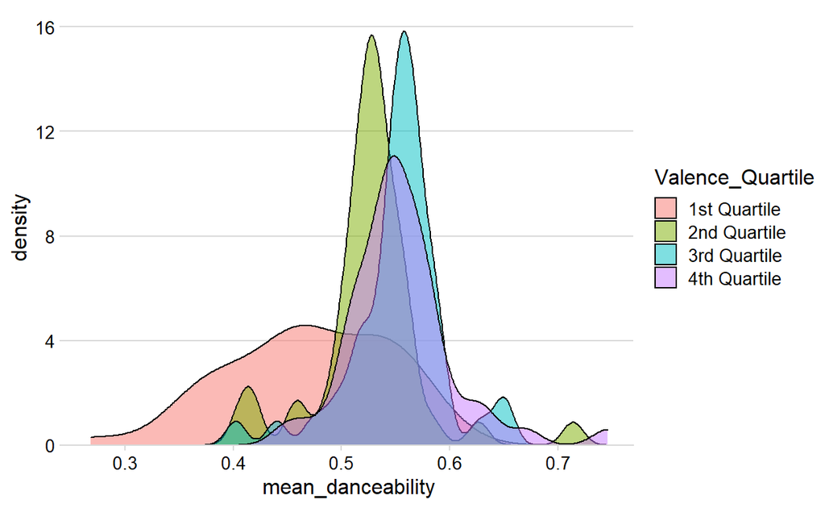

##### Song Tempo

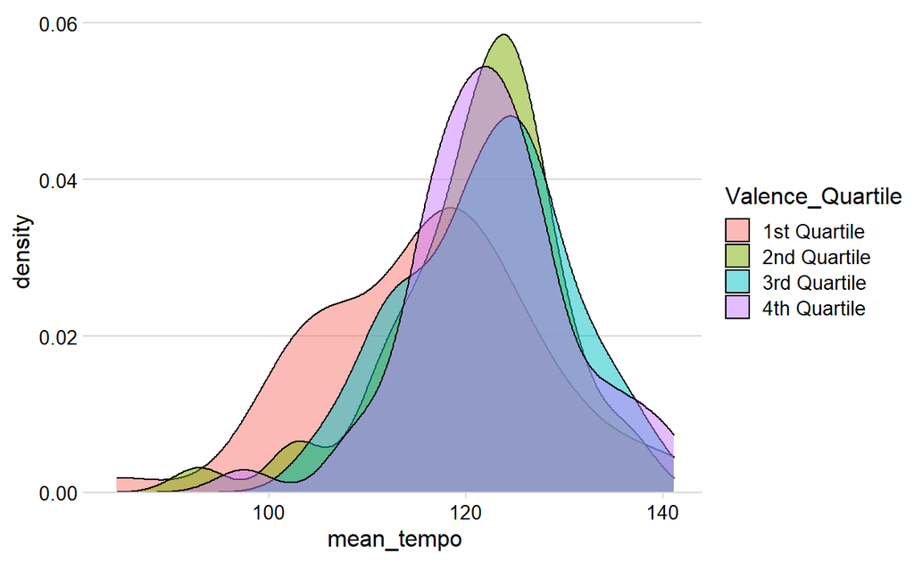

##### Song Liveness

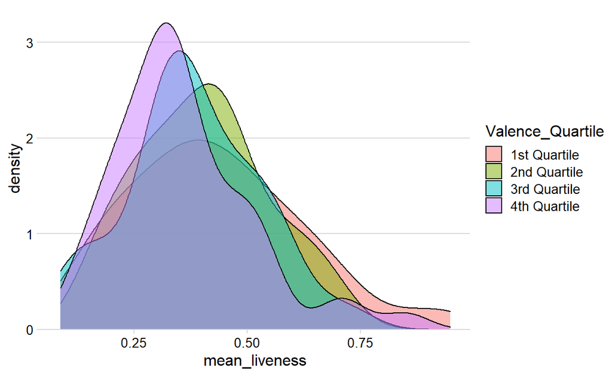

Cool.

Now to wrap this information into my work on the network analysis aspect of the Grateful Dead.

## Correlation

### Top Song Features

I was able to match the “track_id” from the top spotify songs result and match it up to the song features from the main data pull. This gives me the ability to look at the top songs and what classification values they have in common - and how those values are correlated.

#### Features

[output not shown]

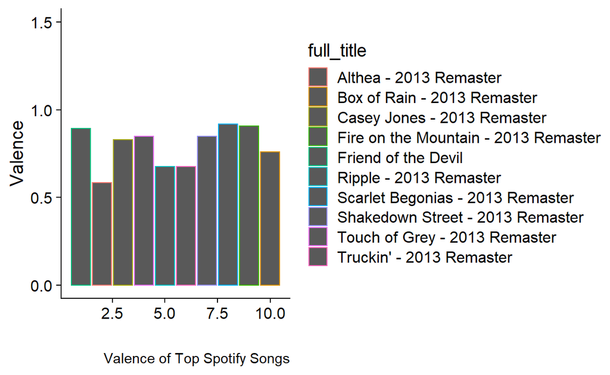

#### Correlation

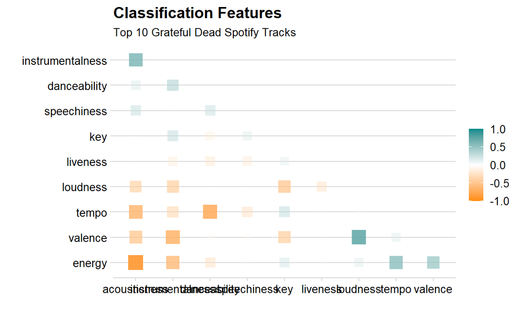